# Project Phase 3 – Model Building

Group 1 · Jason, Jack, Romilson, Barile  
Dataset: UCI Breast Cancer Wisconsin (Diagnostic) via scikit-learn loader

## Dataset context

- Source: [UCI Machine Learning Repository](https://archive.ics.uci.edu/ml/datasets/Breast+Cancer+Wisconsin+%28Diagnostic%29), mirrored inside `sklearn.datasets.load_breast_cancer` for convenient access.
- Task: Predict whether a tumor is malignant or benign from 30 computed measurements in digitized images.
- Rationale: This dataset is compact (569 rows) yet rich enough to satisfy the assignment's requirement for building, explaining, and comparing multiple models.

## Objectives and scope

- Focus on CRISP-DM step 4 by training and comparing logistic regression, random forest, and gradient boosting classifiers.
- Pair every code block with a concise explanation to keep the workflow reproducible.
- Show how preprocessing, modeling, and evaluation choices affect predictions on this health classification problem.

## Import the libraries

All required packages load here so dependency management stays simple when rerunning in a clean environment.

```python
import pandas as pd
import numpy as np
import seaborn as sns
import matplotlib.pyplot as plt

from sklearn.datasets import load_breast_cancer
from sklearn.model_selection import train_test_split
from sklearn.preprocessing import StandardScaler
from sklearn.compose import ColumnTransformer
from sklearn.pipeline import Pipeline
from sklearn.metrics import (
    accuracy_score,
    precision_score,
    recall_score,
    f1_score,
    roc_auc_score,
    classification_report,
    ConfusionMatrixDisplay,
)
from sklearn.linear_model import LogisticRegression
from sklearn.ensemble import RandomForestClassifier, GradientBoostingClassifier

sns.set(style="whitegrid", context="talk")
RANDOM_STATE = 42
```

## Load the dataset

`load_breast_cancer` retrieves the UCI data as a pandas DataFrame with named features, target labels, and metadata for reporting.

```python
data = load_breast_cancer(as_frame=True)
df = data.frame.copy()
df['target'] = df['target'].map({0: 'Malignant', 1: 'Benign'})
print(f"Rows: {df.shape[0]} | Columns: {df.shape[1]}")
display(df.head())
```

```
Rows: 569 | Columns: 31
```

|  | mean radius | mean texture | mean perimeter | mean area | mean smoothness | mean compactness | mean concavity | mean concave points | mean symmetry | mean fractal dimension | ... | worst texture | worst perimeter | worst area | worst smoothness | worst compactness | worst concavity | worst concave points | worst symmetry | worst fractal dimension | target |
| --- | --- | --- | --- | --- | --- | --- | --- | --- | --- | --- | --- | --- | --- | --- | --- | --- | --- | --- | --- | --- | --- |
| 0 | 17.99 | 10.38 | 122.80 | 1001.0 | 0.11840 | 0.27760 | 0.3001 | 0.14710 | 0.2419 | 0.07871 | ... | 17.33 | 184.60 | 2019.0 | 0.1622 | 0.6656 | 0.7119 | 0.2654 | 0.4601 | 0.11890 | Malignant |
| 1 | 20.57 | 17.77 | 132.90 | 1326.0 | 0.08474 | 0.07864 | 0.0869 | 0.07017 | 0.1812 | 0.05667 | ... | 23.41 | 158.80 | 1956.0 | 0.1238 | 0.1866 | 0.2416 | 0.1860 | 0.2750 | 0.08902 | Malignant |
| 2 | 19.69 | 21.25 | 130.00 | 1203.0 | 0.10960 | 0.15990 | 0.1974 | 0.12790 | 0.2069 | 0.05999 | ... | 25.53 | 152.50 | 1709.0 | 0.1444 | 0.4245 | 0.4504 | 0.2430 | 0.3613 | 0.08758 | Malignant |
| 3 | 11.42 | 20.38 | 77.58 | 386.1 | 0.14250 | 0.28390 | 0.2414 | 0.10520 | 0.2597 | 0.09744 | ... | 26.50 | 98.87 | 567.7 | 0.2098 | 0.8663 | 0.6869 | 0.2575 | 0.6638 | 0.17300 | Malignant |
| 4 | 20.29 | 14.34 | 135.10 | 1297.0 | 0.10030 | 0.13280 | 0.1980 | 0.10430 | 0.1809 | 0.05883 | ... | 16.67 | 152.20 | 1575.0 | 0.1374 | 0.2050 | 0.4000 | 0.1625 | 0.2364 | 0.07678 | Malignant |

5 rows × 31 columns

## Data overview and quality checks

Breast cancer measurements are numeric and contain no missing values, yet descriptive statistics still help confirm scales before modeling.

```python
summary = df.describe(include='all').T
print(summary[['count', 'mean', 'std', 'min', 'max']].head(10))
print(f"Total missing values: {int(df.isna().sum().sum())}")
```

```
                        count        mean         std      min      max
mean radius             569.0   14.127292    3.524049    6.981    28.11
mean texture            569.0   19.289649    4.301036     9.71    39.28
mean perimeter          569.0   91.969033   24.298981    43.79    188.5
mean area               569.0  654.889104  351.914129    143.5   2501.0
mean smoothness         569.0     0.09636    0.014064  0.05263   0.1634
mean compactness        569.0    0.104341    0.052813  0.01938   0.3454
mean concavity          569.0    0.088799     0.07972      0.0   0.4268
mean concave points     569.0    0.048919    0.038803      0.0   0.2012
mean symmetry           569.0    0.181162    0.027414    0.106    0.304
mean fractal dimension  569.0    0.062798     0.00706  0.04996  0.09744
Total missing values: 0
```

## Feature engineering

Ratios between "mean" and "worst" morphometric scores capture how a tumor's appearance changes across a cell cluster, so two engineered predictors supplement the original columns.

```python
feature_df = df.copy()
feature_df['radius_ratio'] = feature_df['mean radius'] / feature_df['worst radius']
feature_df['texture_ratio'] = feature_df['mean texture'] / feature_df['worst texture']
feature_df = feature_df.replace([np.inf, -np.inf], np.nan).dropna()
print(feature_df[['radius_ratio', 'texture_ratio']].describe().loc[['mean', 'std']])
```

```
      radius_ratio  texture_ratio
mean      0.879664       0.757918
std       0.057198       0.071781
```

## Exploratory data analysis

This section checks class balance, reviews how representative features relate to the diagnosis label, and highlights multicollinearity that linear models must handle through regularization.

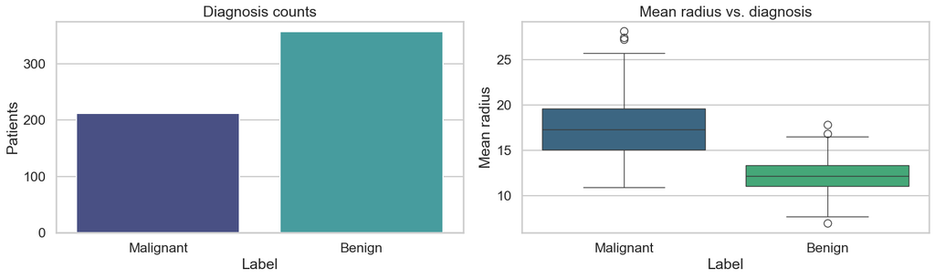

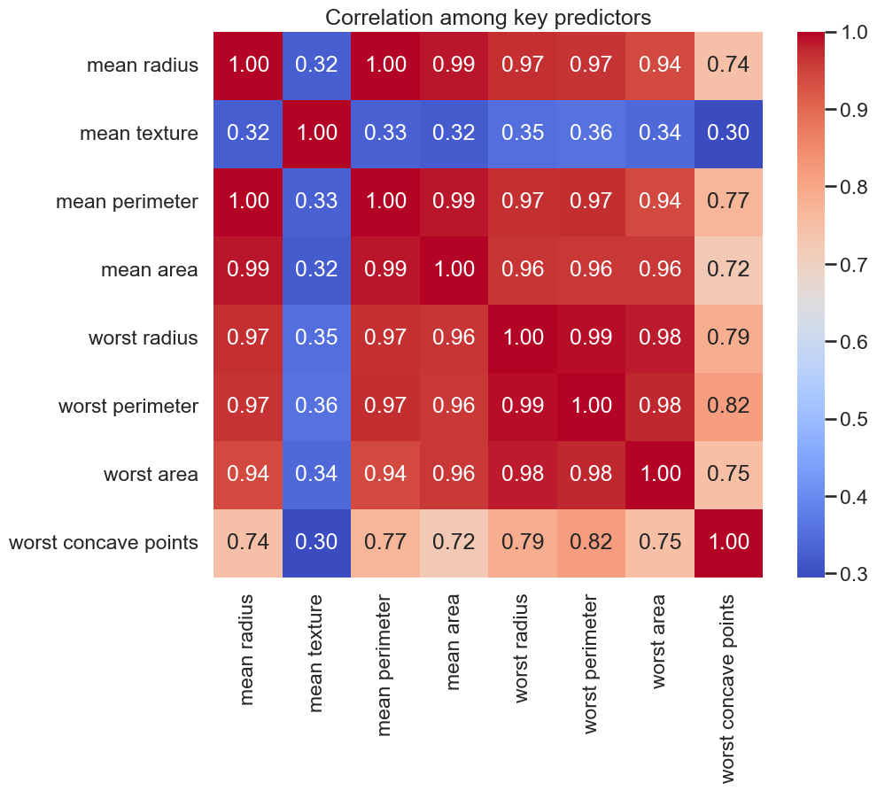

```python
plot_df = feature_df.copy()
fig, axes = plt.subplots(1, 2, figsize=(16, 5))

sns.countplot(x='target', data=plot_df, palette='mako', ax=axes[0])
axes[0].set_title('Diagnosis counts')
axes[0].set_xlabel('Label')
axes[0].set_ylabel('Patients')

sns.boxplot(x='target', y='mean radius', data=plot_df, palette='viridis', ax=axes[1])
axes[1].set_title('Mean radius vs. diagnosis')
axes[1].set_xlabel('Label')
axes[1].set_ylabel('Mean radius')

plt.tight_layout()
plt.show()

corr_features = [
    'mean radius',
    'mean texture',
    'mean perimeter',
    'mean area',
    'worst radius',
    'worst perimeter',
    'worst area',
    'worst concave points'
]
plt.figure(figsize=(10, 8))
sns.heatmap(
    plot_df[corr_features].corr(),
    annot=True,
    cmap='coolwarm',
    fmt='.2f',
)
plt.title('Correlation among key predictors')
plt.show()
```

## Split the data

Hold out 20% of the rows as a stratified test set to evaluate models on unseen tumors and convert the string labels into binary values for modeling.

```python
model_df = feature_df.copy()
model_df['target_binary'] = model_df['target'].map({'Malignant': 0, 'Benign': 1})
X = model_df.drop(columns=['target', 'target_binary'])
y = model_df['target_binary']

X_train, X_test, y_train, y_test = train_test_split(
    X,
    y,
    test_size=0.2,
    stratify=y,
    random_state=RANDOM_STATE,
)
print(f"Train samples: {X_train.shape[0]} | Test samples: {X_test.shape[0]}")
```

```
Train samples: 455 | Test samples: 114
```

## Preprocessing pipeline

All predictors are numeric, so standardization keeps logistic regression and gradient boosting stable while giving the random forest the same transformed inputs for a fair comparison.

```python
numeric_features = X.columns.tolist()
preprocessor = ColumnTransformer(
    transformers=[('num', StandardScaler(), numeric_features)]
)
```

## Train and evaluate three models

The helper function fits each estimator, stores the trained pipelines, and reports accuracy, precision, recall, F1, and ROC-AUC.

```python
def evaluate_model(name, pipeline, X_test, y_test):
    preds = pipeline.predict(X_test)
    proba = pipeline.predict_proba(X_test)[:, 1]
    return {
        'Model': name,
        'Accuracy': accuracy_score(y_test, preds),
        'Precision': precision_score(y_test, preds),
        'Recall': recall_score(y_test, preds),
        'F1': f1_score(y_test, preds),
        'ROC_AUC': roc_auc_score(y_test, proba),
    }

models = {
    'Logistic Regression': LogisticRegression(max_iter=1000, random_state=RANDOM_STATE),
    'Random Forest': RandomForestClassifier(random_state=RANDOM_STATE),
    'Gradient Boosting': GradientBoostingClassifier(random_state=RANDOM_STATE),
}

results = []
fitted_models = {}
for name, estimator in models.items():
    pipe = Pipeline(steps=[('preprocessor', preprocessor), ('model', estimator)])
    pipe.fit(X_train, y_train)
    fitted_models[name] = pipe
    results.append(evaluate_model(name, pipe, X_test, y_test))

results_df = pd.DataFrame(results).set_index('Model').sort_values(by='F1', ascending=False)
display(results_df.style.format(precision=3))
```

| Model | Accuracy | Precision | Recall | F1 | ROC_AUC |
| --- | --- | --- | --- | --- | --- |
| Logistic Regression | 0.982 | 0.986 | 0.986 | 0.986 | 0.997 |
| Random Forest | 0.956 | 0.959 | 0.972 | 0.966 | 0.995 |
| Gradient Boosting | 0.947 | 0.958 | 0.958 | 0.958 | 0.995 |

## Inspect the best model

Plot the confusion matrix for the top-performing classifier to ensure malignant and benign cases remain balanced.

```
Best model based on F1: Logistic Regression
```

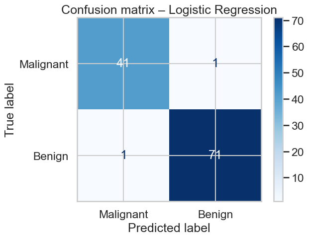

```python
best_model_name = results_df.index[0]
print(f"Best model based on F1: {best_model_name}")
best_pipe = fitted_models[best_model_name]

ConfusionMatrixDisplay.from_estimator(
    best_pipe,
    X_test,
    y_test,
    display_labels=['Malignant', 'Benign'],
    cmap='Blues',
)
plt.title(f'Confusion matrix – {best_model_name}')
plt.show()
```

## Algorithm explanations and default hyperparameters

### Logistic Regression classifier

- **How it works:** Logistic regression models the log-odds of the positive class as a linear combination of the inputs. The sigmoid function turns that score into a probability, yielding a linear decision boundary on standardized features.
- **Default hyperparameters:** `penalty='l2'` applies ridge regularization, `C=1.0` sets the inverse regularization strength, `solver='lbfgs'` performs quasi-Newton optimization, `max_iter=100` caps iterations (increased to 1000 above for convergence), `fit_intercept=True` learns an intercept, and `class_weight=None` treats false positives/negatives equally.

### Random Forest classifier

- **How it works:** A random forest grows many decision trees on bootstrap samples and averages their votes, reducing variance while capturing nonlinear interactions between tumor measurements.
- **Default hyperparameters:** `n_estimators=100` trees, `criterion='gini'` impurity, `max_depth=None` lets trees expand until pure, `max_features='sqrt'` limits features evaluated per split, and `min_samples_split=2` / `min_samples_leaf=1` control node sizes; `bootstrap=True` ensures diverse trees.

### Gradient Boosting classifier

- **How it works:** Gradient boosting adds shallow trees sequentially, each correcting the predecessors' residual errors under the `log_loss` objective. The ensemble forms a strong learner capable of subtle decision boundaries.
- **Default hyperparameters:** `learning_rate=0.1` scales each tree's influence, `n_estimators=100` stages, `subsample=1.0` uses the full dataset per stage, `max_depth=3` limits tree depth, and `min_samples_split=2` / `min_samples_leaf=1` dictate minimum node sizes.